# IRT Analysis: GRM & NRM on Full BFI Run (Llama-2 7B Chat)

Ethan Brown

2026-03-29

## Overview

We fit unidimensional **Graded Response Models (GRM)** and **Nominal Response Models (NRM)** to each Big Five trait from the full BFI run on Llama-2 7B Chat (55,000 prompts: 44 items x 250 preambles x 5 postambles = 1,250 SPIDs).

Each model is fit in two ways:

1. **Top-1 (standard)**: Using the logprob argmax as the categorical response
2. **Soft-evidence**: Using the full logprob distribution via our modified mirt fork

The soft-evidence approach replaces the one-hot categorical likelihood with a weighted sum: $\ell_{ij} = \sum_k \pi_{ijk} \cdot \log P(Y=k \mid \theta_i, a_j, b_j)$.

## 1. Data Preparation

```r
df <- read_csv("results_bfi-full_llama2-7b-chat_0.csv", show_col_types = FALSE)
```

```r
bfi_scales <- list(
  `BFI-EXT` = list(
    items = c("bf1","bf6","bf11","bf16","bf21","bf26","bf31","bf36"),
    reverse = c("bf6","bf21","bf31")
  ),
  `BFI-AGR` = list(
    items = c("bf2","bf7","bf12","bf17","bf22","bf27","bf32","bf37","bf42"),
    reverse = c("bf2","bf12","bf27","bf37")
  ),
  `BFI-CON` = list(
    items = c("bf3","bf8","bf13","bf18","bf23","bf28","bf33","bf38","bf43"),
    reverse = c("bf8","bf18","bf23","bf43")
  ),
  `BFI-NEU` = list(
    items = c("bf4","bf9","bf14","bf19","bf24","bf29","bf34","bf39"),
    reverse = c("bf9","bf24","bf34")
  ),
  `BFI-OPE` = list(
    items = c("bf5","bf10","bf15","bf20","bf25","bf30","bf35","bf40","bf41","bf44"),
    reverse = c("bf35","bf41")
  )
)
```

### Response distribution

The logprob argmax only ever produces categories **1, 3, and 5** — never 2 or 4. This extreme category suppression means mirt remaps our 5-point scale to 3 effective categories.

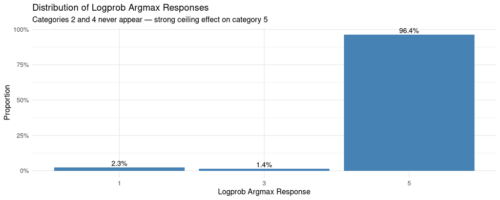

```r
df <- df %>% mutate(response = as.integer(logprob_argmax))

df %>%
  count(response) %>%
  mutate(pct = n / sum(n)) %>%
  ggplot(aes(x = factor(response), y = pct)) +
  geom_col(fill = "steelblue") +
  geom_text(aes(label = sprintf("%.1f%%", pct * 100)), vjust = -0.3, size = 3.5) +
  scale_y_continuous(labels = scales::percent) +
  labs(title = "Distribution of Logprob Argmax Responses",
       subtitle = "Categories 2 and 4 never appear — strong ceiling effect on category 5",
       x = "Logprob Argmax Response", y = "Proportion") +
  theme_minimal()
```

### Building the person-by-item matrix

```r
resp_wide <- df %>%
  select(spid, item_id, response) %>%
  pivot_wider(names_from = item_id, values_from = response) %>%
  arrange(spid)

spid_ids <- resp_wide$spid
N <- nrow(resp_wide)
all_items <- sort(unique(df$item_id))
J <- length(all_items)
K_raw <- 5L
```

**1250 SPIDs** (persons) x **44 items**, fully crossed (no missingness).

### Building the soft-evidence array

We convert 5-category logprob distributions to probabilities and collapse to 3 categories matching the observed data: $p(\text{low}) = p_1 + p_2$, $p(\text{mid}) = p_3$, $p(\text{high}) = p_4 + p_5$.

```r
lp_data <- df %>%
  select(spid, item_id, logprob_1, logprob_2, logprob_3, logprob_4, logprob_5) %>%
  arrange(spid, item_id)

lp_mat <- lp_data %>% select(starts_with("logprob_")) %>% as.matrix()

# Impute NAs with floor
lp_floor <- min(lp_mat, na.rm = TRUE)
n_na <- sum(is.na(lp_mat))
lp_mat[is.na(lp_mat)] <- lp_floor

# Exponentiate and renormalize
prob_mat <- exp(lp_mat)
prob_mat <- prob_mat / rowSums(prob_mat)

# Reshape to N x J x 5
pi_array_5 <- array(prob_mat, dim = c(J, N, K_raw))
pi_array_5 <- aperm(pi_array_5, c(2, 1, 3))

# Collapse to 3 categories
K <- 3L
pi_array <- array(0, dim = c(N, J, K))
pi_array[, , 1] <- pi_array_5[, , 1] + pi_array_5[, , 2]  # low
pi_array[, , 2] <- pi_array_5[, , 3]                        # mid
pi_array[, , 3] <- pi_array_5[, , 4] + pi_array_5[, , 5]  # high
```

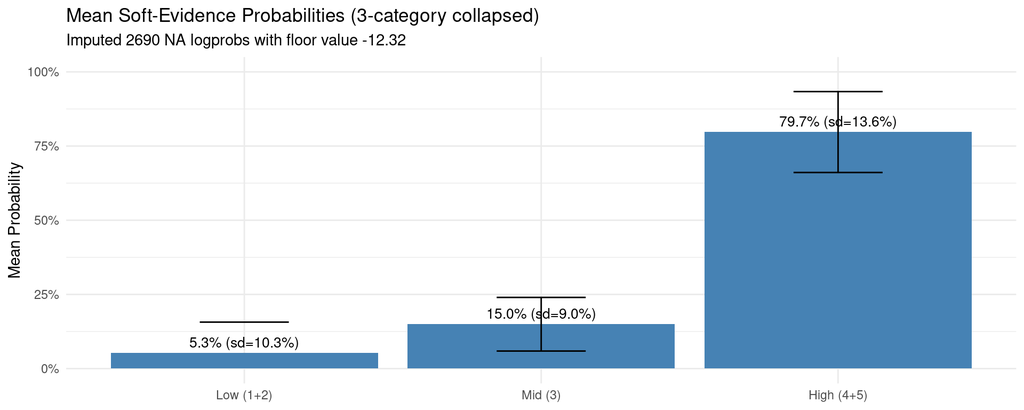

```r
# Summarize the collapsed distributions
cat_probs <- tibble(
  Category = c("Low (1+2)", "Mid (3)", "High (4+5)"),
  Mean = c(mean(pi_array[,,1]), mean(pi_array[,,2]), mean(pi_array[,,3])),
  SD   = c(sd(pi_array[,,1]),   sd(pi_array[,,2]),   sd(pi_array[,,3]))
) %>%
  mutate(Category = fct_inorder(Category))

cat_probs %>%
  ggplot(aes(x = Category, y = Mean)) +
  geom_col(fill = "steelblue") +
  geom_errorbar(aes(ymin = Mean - SD, ymax = pmin(Mean + SD, 1)),
                width = 0.3) +
  geom_text(aes(label = sprintf("%.1f%% (sd=%.1f%%)", Mean*100, SD*100)),
            vjust = -0.5, size = 3.5) +
  scale_y_continuous(labels = scales::percent, limits = c(0, 1)) +
  labs(title = "Mean Soft-Evidence Probabilities (3-category collapsed)",
       subtitle = sprintf("Imputed %d NA logprobs with floor value %.2f", n_na, lp_floor),
       x = NULL, y = "Mean Probability") +
  theme_minimal()
```

The soft evidence is heavily dominated by the “high” category (~80%), with limited between-person variation. This foreshadows the discrimination collapse we observe below.

## 2. Helper Functions

```r
# Build softmat matching mirt's internal itemloc structure
build_softmat_from_model <- function(mod, pi_sub, items, dat_top1) {
  K_vec <- extract.mirt(mod, "K")
  itemloc <- extract.mirt(mod, "itemloc")
  ncols <- sum(K_vec)
  J_sub <- length(items)
  N_local <- dim(pi_sub)[1]
  softmat <- matrix(0, nrow = N_local, ncol = ncols)

  for (jj in 1:J_sub) {
    cols <- itemloc[jj]:(itemloc[jj + 1] - 1)
    if (K_vec[jj] == 3) {
      softmat[, cols] <- pi_sub[, jj, ]
    } else if (K_vec[jj] == 2) {
      # Collapse: low+mid -> cat1, high -> cat2
      softmat[, cols[1]] <- pi_sub[, jj, 1] + pi_sub[, jj, 2]
      softmat[, cols[2]] <- pi_sub[, jj, 3]
    }
  }
  softmat
}

# Extract fit stats into a tidy row
extract_fit <- function(mod, label) {
  if (is.null(mod)) return(NULL)
  tibble(
    Model = label,
    logLik = mod@Fit$logLik,
    AIC = mod@Fit$AIC,
    BIC = mod@Fit$BIC,
    npar = mod@Fit$df - mod@Fit$df  # placeholder
  )
}
```

## 3. Model Fitting

We loop over each Big Five trait, fitting four models:

- **GRM (top-1)**: Standard graded response model on categorical argmax responses
- **GRM (soft)**: Soft-evidence graded response model using logprob distributions
- **NRM (top-1)**: Standard nominal response model on categorical responses
- **NRM (soft)**: Soft-evidence nominal response model

```r
results <- list()

for (scale_id in names(bfi_scales)) {
  items <- bfi_scales[[scale_id]]$items
  rev_items <- bfi_scales[[scale_id]]$reverse
  J_sub <- length(items)
  item_idx <- match(items, all_items)

  # Top-1 response matrix
  dat_top1 <- resp_wide %>% select(all_of(items)) %>% as.data.frame()
  for (ri in rev_items) dat_top1[[ri]] <- 6L - dat_top1[[ri]]

  # Soft-evidence sub-array (reverse-keyed)
  pi_sub <- pi_array[, item_idx, , drop = FALSE]
  for (ri in rev_items) {
    ri_idx <- which(items == ri)
    pi_sub[, ri_idx, ] <- pi_sub[, ri_idx, K:1]
  }

  # 1. GRM top-1
  mod_grm_top1 <- tryCatch(
    mirt(dat_top1, 1, itemtype = "graded", verbose = FALSE, TOL = 1e-4),
    error = function(e) NULL
  )

  # Build softmat from GRM's K structure
  softmat <- if (!is.null(mod_grm_top1)) {
    build_softmat_from_model(mod_grm_top1, pi_sub, items, dat_top1)
  }

  # 2. GRM soft
  mod_grm_soft <- if (!is.null(softmat)) {
    tryCatch(
      mirt(dat_top1, 1, itemtype = "graded", verbose = FALSE, TOL = 1e-4,
           technical = list(softevidence = softmat)),
      error = function(e) NULL
    )
  }

  # 3. NRM top-1
  mod_nrm_top1 <- tryCatch(
    mirt(dat_top1, 1, itemtype = "nominal", verbose = FALSE, TOL = 1e-4),
    error = function(e) NULL
  )

  # Build softmat for NRM (may differ in K)
  softmat_nrm <- if (!is.null(mod_nrm_top1)) {
    build_softmat_from_model(mod_nrm_top1, pi_sub, items, dat_top1)
  }

  # 4. NRM soft
  mod_nrm_soft <- if (!is.null(softmat_nrm)) {
    tryCatch(
      mirt(dat_top1, 1, itemtype = "nominal", verbose = FALSE, TOL = 1e-4,
           technical = list(softevidence = softmat_nrm)),
      error = function(e) NULL
    )
  }

  results[[scale_id]] <- list(
    grm_top1 = mod_grm_top1, grm_soft = mod_grm_soft,
    nrm_top1 = mod_nrm_top1, nrm_soft = mod_nrm_soft,
    items = items, reverse = rev_items,
    dat_top1 = dat_top1, softmat = softmat, pi_sub = pi_sub
  )
}
```

## 4. Results: Top-1 (Standard IRT)

### Fit comparison: GRM vs NRM

```r
top1_summary <- names(results) %>%
  map_dfr(function(s) {
    r <- results[[s]]
    tibble(
      Scale = s,
      J = length(r$items),
      GRM_logLik = if (!is.null(r$grm_top1)) r$grm_top1@Fit$logLik else NA_real_,
      GRM_AIC = if (!is.null(r$grm_top1)) r$grm_top1@Fit$AIC else NA_real_,
      GRM_BIC = if (!is.null(r$grm_top1)) r$grm_top1@Fit$BIC else NA_real_,
      NRM_logLik = if (!is.null(r$nrm_top1)) r$nrm_top1@Fit$logLik else NA_real_,
      NRM_AIC = if (!is.null(r$nrm_top1)) r$nrm_top1@Fit$AIC else NA_real_,
      NRM_BIC = if (!is.null(r$nrm_top1)) r$nrm_top1@Fit$BIC else NA_real_
    ) %>%
      mutate(
        Delta_AIC = GRM_AIC - NRM_AIC,
        Preferred_AIC = ifelse(Delta_AIC < 0, "GRM", "NRM"),
        Preferred_BIC = ifelse(GRM_BIC < NRM_BIC, "GRM", "NRM")
      )
  })

top1_summary %>%
  select(Scale, J, GRM_AIC, NRM_AIC, Delta_AIC, Preferred_AIC, Preferred_BIC) %>%
  knitr::kable(digits = 1, caption = "Top-1 model comparison: GRM vs NRM per trait")
```

Top-1 model comparison: GRM vs NRM per trait

| Scale | J | GRM_AIC | NRM_AIC | Delta_AIC | Preferred_AIC | Preferred_BIC |
| --- | --- | --- | --- | --- | --- | --- |
| BFI-EXT | 8 | 2123.8 | 1886.5 | 237.3 | NRM | NRM |
| BFI-AGR | 9 | 2951.7 | 2938.2 | 13.5 | NRM | GRM |
| BFI-CON | 9 | 2092.2 | 2458.1 | -365.9 | GRM | GRM |
| BFI-NEU | 8 | 1637.0 | 1689.6 | -52.6 | GRM | GRM |
| BFI-OPE | 10 | 1764.4 | 1778.4 | -14.0 | GRM | GRM |

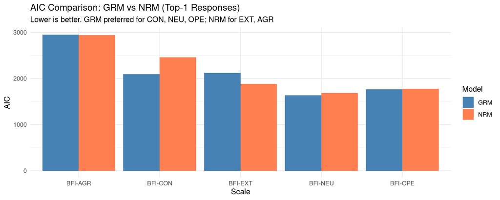

```r
top1_summary %>%
  select(Scale, GRM = GRM_AIC, NRM = NRM_AIC) %>%
  pivot_longer(-Scale, names_to = "Model", values_to = "AIC") %>%
  ggplot(aes(x = Scale, y = AIC, fill = Model)) +
  geom_col(position = "dodge") +
  scale_fill_manual(values = c(GRM = "steelblue", NRM = "coral")) +
  labs(title = "AIC Comparison: GRM vs NRM (Top-1 Responses)",
       subtitle = "Lower is better. GRM preferred for CON, NEU, OPE; NRM for EXT, AGR",
       y = "AIC") +
  theme_minimal()
```

**GRM is preferred for 3 of 5 scales** (CON, NEU, OPE by both AIC and BIC). NRM is preferred for EXT (strongly) and AGR (AIC only; BIC favors GRM). The NRM preference for EXT/AGR may reflect non-ordinal response patterns for those traits under Llama-2’s persona prompting.

### GRM discrimination parameters

```r
grm_params <- names(results) %>%
  map_dfr(function(s) {
    r <- results[[s]]
    if (is.null(r$grm_top1)) return(NULL)
    coefs <- coef(r$grm_top1, simplify = TRUE)$items
    as_tibble(coefs, rownames = "item") %>%
      mutate(Scale = s, .before = 1)
  })

grm_params %>%
  select(Scale, item, a1, d1, d2) %>%
  knitr::kable(digits = 2, caption = "GRM item parameters (top-1)")
```

GRM item parameters (top-1)

| Scale | item | a1 | d1 | d2 |
| --- | --- | --- | --- | --- |
| BFI-EXT | bf1 | 5.68 | 11.09 | 9.83 |
| BFI-EXT | bf6 | -6.34 | -11.57 | -13.06 |
| BFI-EXT | bf11 | 4.81 | 11.76 | 10.65 |
| BFI-EXT | bf16 | 11.43 | 25.41 | 24.51 |
| BFI-EXT | bf21 | -8.38 | -12.61 | -13.98 |
| BFI-EXT | bf26 | 9.82 | 19.39 | 19.26 |
| BFI-EXT | bf31 | -6.90 | -9.02 | -11.59 |
| BFI-EXT | bf36 | 9.57 | 22.90 | 22.18 |
| BFI-AGR | bf2 | -7.31 | -17.16 | -17.83 |
| BFI-AGR | bf7 | 20.75 | 40.76 | 40.42 |
| BFI-AGR | bf12 | -2.86 | -6.07 | -7.81 |
| BFI-AGR | bf17 | 4.03 | 11.00 | 9.01 |
| BFI-AGR | bf22 | 10.62 | 21.32 | 19.84 |
| BFI-AGR | bf27 | -4.11 | -9.40 | -11.38 |
| BFI-AGR | bf32 | 36.71 | 72.91 | 72.08 |
| BFI-AGR | bf37 | -2.48 | -2.94 | -4.90 |
| BFI-AGR | bf42 | 11.91 | 23.47 | 22.45 |
| BFI-CON | bf3 | 5.31 | 13.73 | 12.03 |
| BFI-CON | bf8 | -5.11 | -8.25 | -11.04 |
| BFI-CON | bf13 | 6.85 | 13.11 | 12.37 |
| BFI-CON | bf18 | -5.29 | -10.02 | -10.90 |
| BFI-CON | bf23 | -6.35 | -11.47 | -12.55 |
| BFI-CON | bf28 | 6.15 | 14.92 | 13.47 |
| BFI-CON | bf33 | 3.78 | 9.12 | 7.08 |
| BFI-CON | bf38 | 9.52 | 19.14 | 18.10 |
| BFI-CON | bf43 | -6.64 | -14.50 | -15.69 |
| BFI-NEU | bf4 | 3.91 | 7.39 | 7.14 |
| BFI-NEU | bf9 | -5.15 | -10.80 | -10.87 |
| BFI-NEU | bf14 | 4.68 | 13.28 | 10.68 |
| BFI-NEU | bf19 | 9.30 | 19.34 | 18.34 |
| BFI-NEU | bf24 | -3.41 | -7.94 | -9.82 |
| BFI-NEU | bf29 | 4.67 | 11.61 | 9.15 |
| BFI-NEU | bf34 | -15.38 | -34.22 | -36.05 |
| BFI-NEU | bf39 | 7.32 | 16.46 | 14.42 |
| BFI-OPE | bf5 | 11.72 | 23.63 | 22.69 |
| BFI-OPE | bf10 | 12.34 | 27.86 | 27.68 |
| BFI-OPE | bf15 | 25.03 | 52.27 | NA |
| BFI-OPE | bf20 | 7.69 | 21.12 | 20.69 |
| BFI-OPE | bf25 | 5.55 | 12.79 | 12.71 |
| BFI-OPE | bf30 | 3.99 | 10.47 | 9.16 |
| BFI-OPE | bf35 | -29.55 | -57.33 | -59.68 |
| BFI-OPE | bf40 | 10.37 | 22.13 | 21.11 |
| BFI-OPE | bf41 | -4.56 | -8.07 | -10.20 |
| BFI-OPE | bf44 | 6.24 | 14.62 | 13.56 |

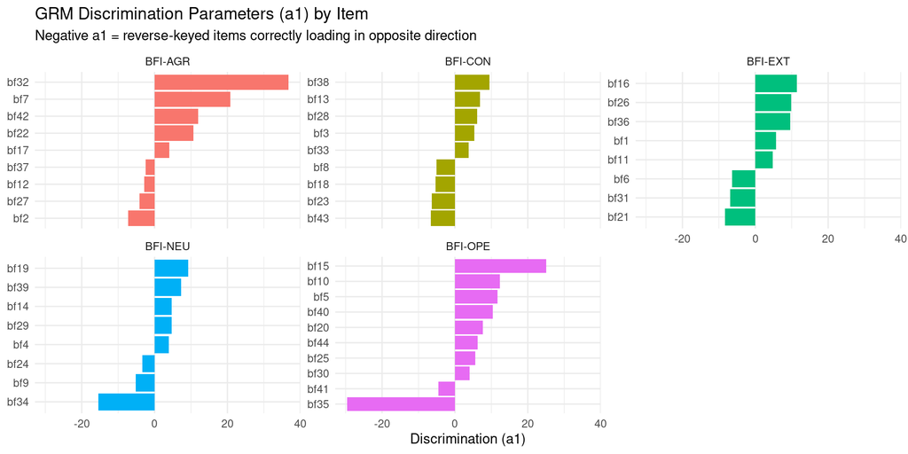

```r
grm_params %>%
  ggplot(aes(x = reorder(item, a1), y = a1, fill = Scale)) +
  geom_col() +
  coord_flip() +
  facet_wrap(~Scale, scales = "free_y") +
  labs(title = "GRM Discrimination Parameters (a1) by Item",
       subtitle = "Negative a1 = reverse-keyed items correctly loading in opposite direction",
       x = NULL, y = "Discrimination (a1)") +
  theme_minimal() +
  theme(legend.position = "none")
```

## 5. Results: Soft-Evidence IRT

### The discrimination collapse

```r
soft_params <- names(results) %>%
  map_dfr(function(s) {
    r <- results[[s]]
    if (is.null(r$grm_soft)) return(NULL)
    coefs <- coef(r$grm_soft, simplify = TRUE)$items
    as_tibble(coefs, rownames = "item") %>%
      mutate(Scale = s, .before = 1)
  })

soft_params %>%
  select(Scale, item, a1, d1, d2) %>%
  knitr::kable(digits = 3, caption = "Soft-evidence GRM item parameters — note a1 = 0 everywhere")
```

Soft-evidence GRM item parameters — note a1 = 0 everywhere

| Scale | item | a1 | d1 | d2 |
| --- | --- | --- | --- | --- |
| BFI-EXT | bf1 | 0 | 2.623 | 1.123 |
| BFI-EXT | bf6 | 0 | -0.998 | -2.585 |
| BFI-EXT | bf11 | 0 | 3.102 | 1.612 |
| BFI-EXT | bf16 | 0 | 3.177 | 1.846 |
| BFI-EXT | bf21 | 0 | -0.831 | -2.137 |
| BFI-EXT | bf26 | 0 | 3.329 | 2.104 |
| BFI-EXT | bf31 | 0 | -0.620 | -2.095 |
| BFI-EXT | bf36 | 0 | 3.301 | 1.795 |
| BFI-AGR | bf2 | 0 | -1.665 | -3.404 |
| BFI-AGR | bf7 | 0 | 2.717 | 1.462 |
| BFI-AGR | bf12 | 0 | -0.978 | -2.611 |
| BFI-AGR | bf17 | 0 | 3.022 | 1.284 |
| BFI-AGR | bf22 | 0 | 2.883 | 1.281 |
| BFI-AGR | bf27 | 0 | -1.296 | -3.060 |
| BFI-AGR | bf32 | 0 | 2.819 | 1.507 |
| BFI-AGR | bf37 | 0 | -0.439 | -1.940 |
| BFI-AGR | bf42 | 0 | 3.011 | 1.403 |
| BFI-CON | bf3 | 0 | 3.318 | 1.662 |
| BFI-CON | bf8 | 0 | -0.930 | -2.789 |
| BFI-CON | bf13 | 0 | 2.735 | 1.506 |
| BFI-CON | bf18 | 0 | -1.200 | -2.730 |
| BFI-CON | bf23 | 0 | -0.969 | -2.343 |
| BFI-CON | bf28 | 0 | 3.298 | 1.634 |
| BFI-CON | bf33 | 0 | 3.106 | 1.146 |
| BFI-CON | bf38 | 0 | 2.867 | 1.510 |
| BFI-CON | bf43 | 0 | -1.426 | -3.079 |
| BFI-NEU | bf4 | 0 | 2.168 | 1.119 |
| BFI-NEU | bf9 | 0 | -1.476 | -3.031 |
| BFI-NEU | bf14 | 0 | 3.605 | 1.428 |
| BFI-NEU | bf19 | 0 | 2.858 | 1.469 |
| BFI-NEU | bf24 | 0 | -1.423 | -3.377 |
| BFI-NEU | bf29 | 0 | 3.228 | 1.239 |
| BFI-NEU | bf34 | 0 | -1.786 | -3.330 |
| BFI-NEU | bf39 | 0 | 2.990 | 1.197 |
| BFI-OPE | bf5 | 0 | 2.857 | 1.636 |
| BFI-OPE | bf10 | 0 | 3.165 | 1.834 |
| BFI-OPE | bf15 | 0 | 1.985 | NA |
| BFI-OPE | bf20 | 0 | 3.727 | 2.046 |
| BFI-OPE | bf25 | 0 | 3.029 | 1.852 |
| BFI-OPE | bf30 | 0 | 3.338 | 1.651 |
| BFI-OPE | bf35 | 0 | -1.321 | -2.716 |
| BFI-OPE | bf40 | 0 | 3.143 | 1.647 |
| BFI-OPE | bf41 | 0 | -0.994 | -2.793 |
| BFI-OPE | bf44 | 0 | 3.290 | 1.596 |

**All discrimination parameters collapse to zero.** The soft-evidence GRM cannot recover a latent trait dimension because the logprob distributions are too homogeneous across persons.

### Why soft evidence fails here

[figure not shown]

```r
# Show the between-person variation in soft evidence for a sample scale (EXT)
ext_pi <- results[["BFI-EXT"]]$pi_sub
ext_items <- results[["BFI-EXT"]]$items

# For each person x item, compute entropy of the 3-cat distribution
entropy_data <- expand_grid(
  person = 1:N,
  item_idx = 1:length(ext_items)
) %>%
  mutate(
    item = ext_items[item_idx],
    p_low  = map2_dbl(person, item_idx, ~ ext_pi[.x, .y, 1]),
    p_mid  = map2_dbl(person, item_idx, ~ ext_pi[.x, .y, 2]),
    p_high = map2_dbl(person, item_idx, ~ ext_pi[.x, .y, 3])
  ) %>%
  rowwise() %>%
  mutate(
    entropy = {
      p <- c(p_low, p_mid, p_high)
      p <- p[p > 0]
      -sum(p * log(p))
    },
    normed_entropy = entropy / log(3)
  ) %>%
  ungroup()

entropy_data %>%
  ggplot(aes(x = p_high)) +
  geom_histogram(bins = 50, fill = "steelblue", color = "white") +
  facet_wrap(~item, nrow = 2) +
  labs(title = "Distribution of p(high) Across SPIDs — BFI Extraversion Items",
       subtitle = "Near-zero between-person variation: most SPIDs have p(high) ≈ 0.75–0.85",
       x = "p(high) = p4 + p5", y = "Count") +
  theme_minimal()
```

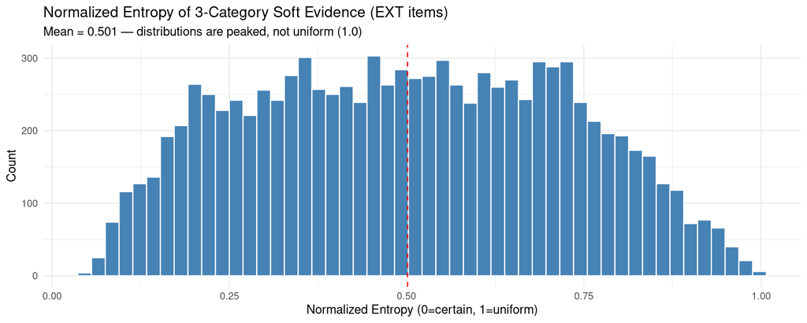

```r
entropy_data %>%
  ggplot(aes(x = normed_entropy)) +
  geom_histogram(bins = 50, fill = "steelblue", color = "white") +
  geom_vline(xintercept = mean(entropy_data$normed_entropy),
             linetype = "dashed", color = "red") +
  labs(title = "Normalized Entropy of 3-Category Soft Evidence (EXT items)",
       subtitle = sprintf("Mean = %.3f — distributions are peaked, not uniform (1.0)",
                          mean(entropy_data$normed_entropy)),
       x = "Normalized Entropy (0=certain, 1=uniform)", y = "Count") +
  theme_minimal()
```

### Soft-evidence fit comparison

```r
soft_summary <- names(results) %>%
  map_dfr(function(s) {
    r <- results[[s]]
    tibble(
      Scale = s,
      GRM_soft_AIC = if (!is.null(r$grm_soft)) r$grm_soft@Fit$AIC else NA_real_,
      NRM_soft_AIC = if (!is.null(r$nrm_soft)) r$nrm_soft@Fit$AIC else NA_real_,
      Delta_AIC = GRM_soft_AIC - NRM_soft_AIC,
      Preferred = ifelse(Delta_AIC < 0, "GRM", "NRM")
    )
  })

soft_summary %>%
  knitr::kable(digits = 1, caption = "Soft-evidence model comparison (all degenerate)")
```

Soft-evidence model comparison (all degenerate)

| Scale | GRM_soft_AIC | NRM_soft_AIC | Delta_AIC | Preferred |
| --- | --- | --- | --- | --- |
| BFI-EXT | 9046.8 | 9063.0 | -16.2 | GRM |
| BFI-AGR | 10662.0 | 10679.7 | -17.7 | GRM |
| BFI-CON | 9976.8 | 9994.9 | -18.1 | GRM |
| BFI-NEU | 8391.2 | 8407.1 | -16.0 | GRM |
| BFI-OPE | 8694.8 | 8712.7 | -18.0 | GRM |

GRM is consistently preferred over NRM for soft evidence, but only because GRM uses fewer parameters to describe the same intercept-only model. Both have a1 ≈ 0.

## 6. Comparing Top-1 vs Soft-Evidence GRM

```r
comparison <- names(results) %>%
  map_dfr(function(s) {
    r <- results[[s]]
    if (is.null(r$grm_top1) || is.null(r$grm_soft)) return(NULL)
    coefs_t <- coef(r$grm_top1, simplify = TRUE)$items
    coefs_s <- coef(r$grm_soft, simplify = TRUE)$items
    shared <- intersect(colnames(coefs_t), colnames(coefs_s))
    diff_mat <- coefs_s[, shared] - coefs_t[, shared]
    a_cor <- cor(coefs_t[, "a1"], coefs_s[, "a1"])

    tibble(
      Scale = s,
      mean_abs_diff = mean(abs(diff_mat), na.rm = TRUE),
      max_abs_diff = max(abs(diff_mat), na.rm = TRUE),
      a1_correlation = a_cor
    )
  })

comparison %>%
  knitr::kable(digits = 3,
               caption = "Parameter differences: soft-evidence vs top-1 GRM")
```

Parameter differences: soft-evidence vs top-1 GRM

| Scale | mean_abs_diff | max_abs_diff | a1_correlation |
| --- | --- | --- | --- |
| BFI-EXT | 11.603 | 22.668 | -0.364 |
| BFI-AGR | 17.582 | 70.571 | -0.740 |
| BFI-CON | 9.046 | 16.593 | 0.113 |
| BFI-NEU | 10.651 | 32.718 | 0.330 |
| BFI-OPE | 17.937 | 56.961 | 0.142 |

The correlation between top-1 and soft-evidence discrimination is near zero or negative — confirming the soft-evidence models are not recovering the same latent structure. This is expected given the a1=0 collapse.

## 7. Summary

### Key findings

| Finding | Detail |
| --- | --- |
| **Top-1 GRM works well** | Strong discrimination, correct reverse-keying direction |
| **GRM preferred for 3/5 traits** | CON, NEU, OPE by AIC/BIC |
| **NRM preferred for 2/5 traits** | EXT (strongly), AGR (AIC only) |
| **Soft evidence collapses** | All a1 = 0; no latent dimension recovered |
| **Root cause** | Ceiling effect: ~80% probability on “high”, minimal between-person variation |
| **Category suppression confirmed** | Categories 2 and 4 *never* appear as argmax across 55K prompts |

### Implications

1. **Standard (top-1) IRT is viable** for LLM personality measurement, even with only 3 effective response categories. The preamble-induced trait variation creates meaningful person-level differences that IRT can recover.
2. **Soft-evidence IRT needs models with more response variability.** The approach is theoretically sound (validated with simulated data in `mirt/tests/test_softevidence.R`), but Llama-2’s near-deterministic responses leave too little distributional signal.
3. **Multi-model comparison** may be more informative for soft evidence — models with different ceiling tendencies would provide actual distributional variation.
4. **The 5-category collapse to 3** loses information. Future work could explore models that actually use categories 2 and 4 (perhaps with different prompt framing or less instruction-tuned models).

```
## Session info:
```

```
##   mirt version: 1.46.2
```

```
##   R version: R version 4.5.2 (2025-10-31)
```